# html

## Load Data

```python
import pandas as pd
import warnings
warnings.filterwarnings('ignore')

user_activity_df = pd.read_csv('https://storage.googleapis.com/datalynn-datasets/interview-challenge/technology/Spotify_Advertising/UserActivity.csv')
ad_performance_df = pd.read_csv('https://storage.googleapis.com/datalynn-datasets/interview-challenge/technology/Spotify_Advertising/AdPerformance.csv')
```

## Questions 1:

**Scenario**: Recently, we noticed a pattern of users with specific search histories interacting more with particular ad categories.

- Given the `UserActivity` table, derive a new column representing the predominant search theme for each user using SQL. Further, merge this with the `AdPerformance` table to analyze if there's a strong correlation between a user's search theme and the ad category they interact with.

## Solution

### **Hints:**

1. **Data Inspection & Cleaning**:
   - Inspect data in `UserActivity` and `AdPerformance` tables.
   - Handle missing values and ensure the data types are appropriate.
2. **Feature Engineering**:
   - Extract the predominant search theme for each user from the `searchHistory` column.
3. **Data Merging**:
   - Combine the `UserActivity` table (with the new search theme column) and the `AdPerformance` table based on the `userID`.
4. **Correlation Analysis**:
   - Compute the correlation between the search theme of users and the ad category they interact with.
5. **Visualization & Interpretation**:
   - Visualize the findings.
   - Interpret the results and provide business insights.

### Step 1: Data Inspection & Cleaning

```python
import sqlite3

# Create an in-memory database.
conn = sqlite3.connect(':memory:')

# Convert pandas dataframe to SQL tables
user_activity_df.to_sql('UserActivity', conn, index=False)
ad_performance_df.to_sql('AdPerformance', conn, index=False)

# Check for missing values in UserActivity
query = "SELECT * FROM UserActivity WHERE (userID IS NULL OR searchHistory IS NULL);"
missing_data_user_activity = pd.read_sql(query, conn)
print(f"Missing data in UserActivity: {len(missing_data_user_activity)} rows")

# Check for missing values in AdPerformance
query = "SELECT * FROM AdPerformance WHERE (userID IS NULL OR adCategory IS NULL);"
missing_data_ad_performance = pd.read_sql(query, conn)
print(f"Missing data in AdPerformance: {len(missing_data_ad_performance)} rows")
```

```
Missing data in UserActivity: 0 rows
Missing data in AdPerformance: 0 rows
```

### Step 2: Feature Engineering

Using SQL's string functions to analyze the `searchHistory` column and extract predominant themes.

```python
query = """
CREATE TEMP TABLE UserThemes AS
SELECT
    userID,
    CASE
        WHEN searchHistory LIKE '%pop%' THEN 'pop'
        WHEN searchHistory LIKE '%rock%' THEN 'rock'
        WHEN searchHistory LIKE '%jazz%' THEN 'jazz'
        ELSE 'other'
    END as predominantTheme
FROM UserActivity;
"""
conn.execute(query)
```

```
<sqlite3.Cursor at 0x7e6ca3e44dc0>
```

### Step 3: Data Merging

Join the `UserThemes` table with the `AdPerformance` table on `userID`.

```python
query = """
CREATE TEMP TABLE MergedData AS
SELECT
    a.userID,
    a.predominantTheme,
    b.adCategory,
    b.interaction
FROM
    UserThemes a
JOIN
    AdPerformance b
ON
    a.userID = b.userID;
"""
conn.execute(query)
```

```
<sqlite3.Cursor at 0x7e6ca3e45140>
```

### Step 4: Correlation Analysis

Group by both the predominant theme and ad category, counting interactions.

```python
query = """
SELECT
    predominantTheme,
    adCategory,
    SUM(CASE WHEN interaction = 1 THEN 1 ELSE 0 END) AS interaction_count
FROM
    MergedData
GROUP BY
    predominantTheme, adCategory;
"""
interaction_counts = pd.read_sql(query, conn)
print(interaction_counts)
```

```
   predominantTheme adCategory  interaction_count
0              jazz    Fashion                  6
1              jazz       Food                 14
2              jazz       Tech                 12
3              jazz     Travel                 12
4             other    Fashion                 26
5             other       Food                 21
6             other       Tech                 28
7             other     Travel                 19
8               pop    Fashion                 17
9               pop       Food                 13
10              pop       Tech                 18
11              pop     Travel                 10
12             rock    Fashion                 11
13             rock       Food                 14
14             rock       Tech                  5
15             rock     Travel                 19
```

### Step 5: Visualization & Interpretation

If you would like to visualize the data, consider using a heatmap using `seaborn`:

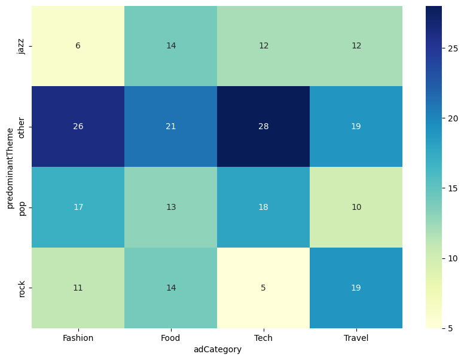

```python
import seaborn as sns
import matplotlib.pyplot as plt

# Pivot the data for heatmap
heatmap_data = interaction_counts.pivot('predominantTheme', 'adCategory', 'interaction_count')
plt.figure(figsize=(10,7))
sns.heatmap(heatmap_data, annot=True, cmap="YlGnBu")
plt.show()
```

**Comments on the Result**:

The heatmap illustrates the frequency of user interactions between their predominant search themes and various ad categories. Notably, users with the 'other' search theme have the highest interaction with 'Tech' ads, totaling 28 occurrences. This insight is crucial for Spotify's ad targeting, suggesting that aligning ads with user search themes can enhance engagement and ad revenue potential.

## Questions 2:

**Scenario**: To avoid disrupting user experience, it's crucial to identify the optimal time intervals during which users might be more receptive to ads.

- Using the `UserActivity` table, can you determine any patterns or specific timeframes where users are more likely to tolerate or interact with an ad, based on their `listeningDuration`?

## Solution

### **Hints**:

1. **Data Manipulation & Cleaning**:
   - Check for missing values in `user_activity_df`.
   - Ensure appropriate data types for each column, especially for datetime.
   - Convert `listeningDuration` into more comprehensive units if needed.
2. **Analyze Listening Duration vs. Ad Interactions**:
   - Combine the `UserActivity` table with the `AdPerformance` table to correlate `listeningDuration` and ad `interaction`.
   - Group data by `listeningDuration` intervals (e.g., 0-5 mins, 5-10 mins) and calculate the percentage of ad interactions for each interval.
3. **Visualization & Interpretation**:
   - Plot the ad interaction percentage against listening duration intervals.
   - Derive insights from the visualization results.

### **Step 1: Data Manipulation & Cleaning**:

```python
# Checking for missing values in user_activity_df
print(user_activity_df.isnull().sum())

# Checking data types
print(user_activity_df.dtypes)
```

```
userID               0
songID               0
searchHistory        0
listeningDuration    0
adPlayedTime         0
demographicDetail    0
dtype: int64
userID                 int64
songID                 int64
searchHistory         object
listeningDuration    float64
adPlayedTime          object
demographicDetail     object
dtype: object
```

### **Step 2: Analyze Listening Duration vs. Ad Interactions**:

First, we need to merge the two dataframes based on `userID` to correlate the listening duration of a user with their ad interactions. Then, we will group the data by listening duration intervals and compute the percentage of positive ad interactions for each interval.

```python
# Merging the two dataframes
merged_df = pd.merge(user_activity_df, ad_performance_df, on='userID')

# Bin listening durations into intervals for easier analysis
bins = [0, 5, 10, 15, 20, 25, 30, 35, 40, 45, 50, 55, 60]  # Example bin intervals, can be adjusted
labels = ['0-5', '5-10', '10-15', '15-20', '20-25', '25-30', '30-35', '35-40', '40-45', '45-50', '50-55', '55-60']
merged_df['duration_interval'] = pd.cut(merged_df['listeningDuration'], bins=bins, labels=labels, right=False)

# Calculate interaction percentage for each interval
interaction_percentage = merged_df.groupby('duration_interval')['interaction'].mean() * 100
print(interaction_percentage)
```

```
duration_interval
0-5      78.125000
5-10     87.951807
10-15    80.000000
15-20    87.500000
20-25    85.714286
25-30    84.615385
30-35    77.777778
35-40    71.428571
40-45    71.428571
45-50    69.230769
50-55    81.250000
55-60          NaN
Name: interaction, dtype: float64
```

### **Step 3: Visualization & Interpretation**:

Let's visualize the percentage of positive ad interactions across different listening duration intervals.

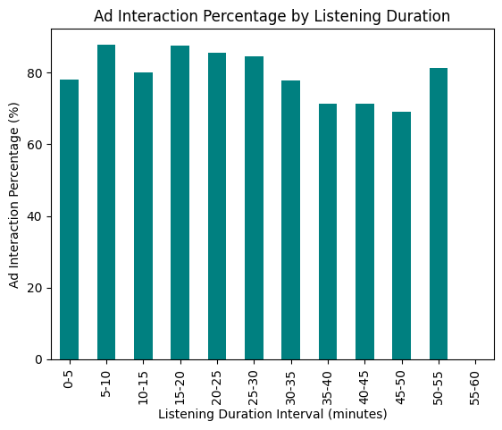

```python
import matplotlib.pyplot as plt

interaction_percentage.plot(kind='bar', color='teal')
plt.title('Ad Interaction Percentage by Listening Duration')
plt.xlabel('Listening Duration Interval (minutes)')
plt.ylabel('Ad Interaction Percentage (%)')
plt.show()
```

#### **Comments on the Result**:

Such insights will guide Spotify's Advertising department on when to present ads for optimal user receptivity. They can strategically place ads during timeframes when users are more likely to engage, thereby enhancing the ad's efficacy and ensuring a pleasant user experience.

## Questions 3:

**Scenario**: We've been experimenting with the success rate of our ads, as derived from their performance on other platforms. We believe this might be a predictor of whether a user would interact with the ad on Spotify.

- Given the `AdPerformance` table, can you construct a model predicting `interaction` based on `adSuccessRate` and `adCategory`? Clearly specify the target variable and its type.
  - **Target Variable**: `interaction`
  - **Target Variable Type**: Boolean

## Solution

### **Hints:**

1. **Data Exploration**:
   - Inspect the AdPerformance data for any anomalies or missing values.
   - Look at the distribution of the `adSuccessRate` and the frequency of each `adCategory`.
2. **Data Preprocessing**:
   - Handle missing values if any.
   - Convert categorical variables to a format suitable for modeling (e.g., one-hot encoding).
3. **Model Selection & Training**:
   - Given the binary nature of the target variable (`interaction`), choose a suitable classifier (e.g., logistic regression).
   - Split the data into training and test sets.
   - Train the model using the training set and evaluate its performance using the test set.
4. **Evaluation & Interpretation**:
   - Use appropriate metrics (like accuracy, precision, recall) to evaluate the model's performance.
   - Comment on the importance of features.

### Step 1: Data Exploration:

Let's inspect the `AdPerformance` dataframe.

```
   adID  userID  interaction adCategory  adSuccessRate
0     1     752         True       Food       0.234203
1     2     331         True    Fashion       0.219554
2     3     333         True       Food       0.959863
3     4      50        False       Tech       0.616300
4     5     523         True       Tech       0.556878
adID             0
userID           0
interaction      0
adCategory       0
adSuccessRate    0
dtype: int64
```

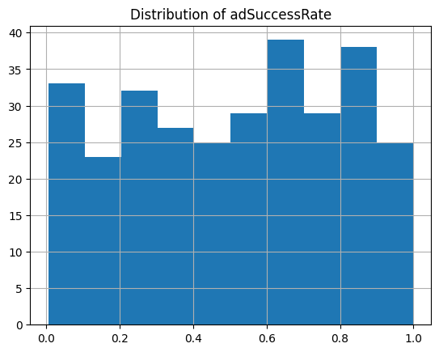

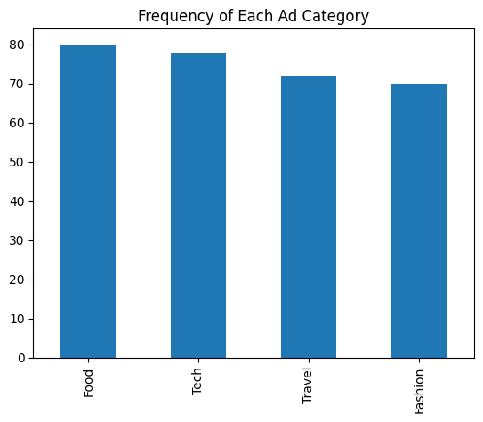

```python
# Inspect the first few rows of the dataframe
print(ad_performance_df.head())

# Check for missing values
print(ad_performance_df.isnull().sum())

# View distribution of adSuccessRate
ad_performance_df['adSuccessRate'].hist()
plt.title("Distribution of adSuccessRate")
plt.show()

# View frequency of each adCategory
ad_performance_df['adCategory'].value_counts().plot(kind='bar')
plt.title("Frequency of Each Ad Category")
plt.show()
```

### Step 2: Data Preprocessing:

```python
# One-hot encoding for adCategory
ad_performance_encoded_df = pd.get_dummies(ad_performance_df, columns=['adCategory'], drop_first=True)

print(ad_performance_encoded_df.head())
```

```
   adID  userID  interaction  adSuccessRate  adCategory_Food  adCategory_Tech  \
0     1     752         True       0.234203                1                0
1     2     331         True       0.219554                0                0
2     3     333         True       0.959863                1                0
3     4      50        False       0.616300                0                1
4     5     523         True       0.556878                0                1

   adCategory_Travel
0                  0
1                  0
2                  0
3                  0
4                  0
```

### Step 3: Model Selection & Training:

For this example, let's use logistic regression.

```python
from sklearn.model_selection import train_test_split
from sklearn.linear_model import LogisticRegression
from sklearn.metrics import accuracy_score, classification_report

# Split the data into training and test sets
X = ad_performance_encoded_df.drop('interaction', axis=1)
y = ad_performance_encoded_df['interaction']

X_train, X_test, y_train, y_test = train_test_split(X, y, test_size=0.3, random_state=42)

# Initialize and train the logistic regression model
model = LogisticRegression()
model.fit(X_train, y_train)

# Make predictions and evaluate the model
y_pred = model.predict(X_test)
print("Accuracy:", accuracy_score(y_test, y_pred))
print(classification_report(y_test, y_pred))
```

```
Accuracy: 0.8222222222222222
              precision    recall  f1-score   support

       False       0.00      0.00      0.00        16
        True       0.82      1.00      0.90        74

    accuracy                           0.82        90
   macro avg       0.41      0.50      0.45        90
weighted avg       0.68      0.82      0.74        90
```

### Step 4: Evaluation & Interpretation:

Given the output:

- **Accuracy**: The model correctly predicts whether a user will interact with an ad 82.22% of the time. At first glance, this may seem like a reasonable performance. However, a deeper dive into the metrics reveals more about the model's behavior.
- **Precision for 'True' Class**: This metric is 0.82, which means that of all the instances where our model predicts that a user will interact with an ad, 82% of the time it's correct.
- **Recall for 'True' Class**: The recall for the 'True' class is 1.00, indicating that our model identifies 100% of all the actual interactions. This means that the model does not miss out on any potential interactions, but this high recall comes at the expense of precision for the 'False' class.
- **Precision & Recall for 'False' Class**: Both of these metrics are 0.00, meaning our model never correctly predicts an instance where a user doesn't interact with an ad. Every time the actual interaction is 'False', our model gets it wrong.
- **F1-Score**: The harmonic mean of precision and recall for 'True' interactions is 0.90, which suggests a balance for this class, but it's 0.00 for 'False' interactions, highlighting the model's inability to predict them correctly.
- **Macro Avg vs. Weighted Avg**: The macro average is a simple average of the metric for each class, while the weighted average takes into account the imbalance in the dataset. The low macro average (0.45) compared to the accuracy (0.82) indicates that the model is biased towards the majority class ('True') and struggles with the minority class ('False').

**Comments on the Result**:

1. **Imbalanced Dataset**: The results suggest that there might be a significant class imbalance in the dataset. The model seems to be biased towards predicting interactions because it encounters them more frequently during training.
2. **Potential Overfitting**: The perfect recall score for the 'True' class suggests potential overfitting. The model might be too fit to the training data and fails to generalize well to new, unseen data.
3. **Need for Further Refinement**: The model's inability to predict 'False' interactions indicates that more refinement is needed. Techniques like oversampling the minority class, using synthetic data generation methods like SMOTE, or trying more complex algorithms that handle imbalances effectively can be explored.
4. **Model Selection**: It might be beneficial to explore other models or ensemble methods that handle class imbalance better. Random forests, gradient boosting machines, or neural networks might offer improved performance.

By understanding these insights, Spotify can iterate on its modeling approach to improve ad targeting.

## Questions 4:

**Scenario**: We're planning a new ad campaign and would like to understand the impact of this campaign in the coming months. However, post-campaign, we might not know which users were exposed to it.

- How would you set up an experiment or use available data to measure the campaign's impact on user interaction with ads?

## Solution

### **Hints**:

1. **Experiment Design**:
   - Segment users based on desired criteria like `demographicDetail` or `listeningDuration`.
   - Design a strategy to expose these segments to the new ad campaign.
2. **Measurement Strategy**:
   - Utilize interaction rate (e.g., percentage of users who interact with the ad) as the primary metric.
   - Measure differences in interaction rates between users exposed and not exposed to the campaign.
3. **Statistical Tests**:
   - Use statistical tests to ascertain significant differences in interaction rates.
4. **Implementation & Evaluation**:
   - Implement the campaign and consistently track the outcomes.

### **Step 1: Experiment Design**:

**Segmentation**: Based on the primary goal, segment users by their `demographicDetail` or `listeningDuration`.

**Randomized Controlled Trial (RCT)**: Divide users into two distinct groups:

- **Control Group**: Will not experience the new ad campaign.
- **Treatment Group**: Will be exposed to the new ad campaign.

Ensure the segmentation is random, but the segments are balanced in both groups.

### **Step 2: Measurement Strategy**:

For determining the campaign's impact:

```python
# Compute the total number of ads a user interacts with and the total number shown to a user
interaction_counts = ad_performance_df.groupby('userID')['interaction'].agg(['sum', 'count']).reset_index()
interaction_counts.columns = ['userID', 'interacted_ads', 'total_ads']

# Derive interaction rate for each user
interaction_counts['interaction_rate'] = interaction_counts['interacted_ads'] / interaction_counts['total_ads']
```

### **Step 3: Statistical Tests**:

After the campaign's execution, compare the interaction rates of the control and treatment groups. An appropriate test for this comparison is an Independent Two-sample T-test (assuming a sufficiently large sample size and the normality assumptions are met). The null hypothesis posits no difference in interaction rates between the groups.

### **Step 4: Implementation & Evaluation**:

Execute the campaign for the treatment group and consistently monitor the interaction rates for both groups. After a designated period, assess the outcomes to verify if the new ad campaign was effective.

**Comments**:

This solution's purpose is to identify whether the new ad campaign has a positive effect on user interactions. If a statistically significant increase in the interaction rate is observed in the treatment group post-campaign relative to the control group, it indicates campaign effectiveness. Nonetheless, continuous monitoring and re-assessment are crucial to account for external factors like seasonality, simultaneous campaigns, and overarching market dynamics.